# Optimal Treatment Analysis

## Outcome Variable

**Outcome Variable:** whz

## Predictor Variables

**Intervention Variable:** nrooms

**Adjustment Set:**

- arm
- sex
- W_mage
- meducyrs
- feducyrs
- hhwealth_quart
- hfoodsec
- W_mhtcm
- W_mwtkg
- W_mbmi
- W_nchldlt5
- W_parity
- impfloor
- impsan
- safeh20
- delta_W_mage
- delta_meducyrs
- delta_feducyrs
- delta_hhwealth_quart
- delta_hfoodsec
- delta_W_mhtcm
- delta_W_mwtkg
- delta_W_mbmi
- delta_W_nchldlt5
- delta_W_parity
- delta_impfloor
- delta_impsan
- delta_safeh20

## Stratifying Variables

The analysis was stratified on these variable(s):

- agecat
- studyid
- country

## Data Summary

| agecat | studyid | country | nrooms | n_cell | n |
| --- | --- | --- | --- | --- | --- |
| Birth | CMC-V-BCS-2002 | INDIA | 4+ | 5 | 86 |
| Birth | CMC-V-BCS-2002 | INDIA | 1 | 35 | 86 |
| Birth | CMC-V-BCS-2002 | INDIA | 2 | 27 | 86 |
| Birth | CMC-V-BCS-2002 | INDIA | 3 | 19 | 86 |
| Birth | COHORTS | INDIA | 4+ | 90 | 4454 |
| Birth | COHORTS | INDIA | 1 | 2879 | 4454 |
| Birth | COHORTS | INDIA | 2 | 1328 | 4454 |
| Birth | COHORTS | INDIA | 3 | 157 | 4454 |
| Birth | CONTENT | PERU | 4+ | 1 | 2 |
| Birth | CONTENT | PERU | 1 | 0 | 2 |
| Birth | CONTENT | PERU | 2 | 1 | 2 |
| Birth | CONTENT | PERU | 3 | 0 | 2 |
| Birth | GMS-Nepal | NEPAL | 4+ | 297 | 641 |
| Birth | GMS-Nepal | NEPAL | 1 | 42 | 641 |
| Birth | GMS-Nepal | NEPAL | 2 | 135 | 641 |
| Birth | GMS-Nepal | NEPAL | 3 | 167 | 641 |
| Birth | IRC | INDIA | 4+ | 14 | 341 |
| Birth | IRC | INDIA | 1 | 156 | 341 |
| Birth | IRC | INDIA | 2 | 140 | 341 |
| Birth | IRC | INDIA | 3 | 31 | 341 |
| Birth | JiVitA-3 | BANGLADESH | 4+ | 662 | 17989 |
| Birth | JiVitA-3 | BANGLADESH | 1 | 11170 | 17989 |
| Birth | JiVitA-3 | BANGLADESH | 2 | 4609 | 17989 |
| Birth | JiVitA-3 | BANGLADESH | 3 | 1548 | 17989 |
| Birth | JiVitA-4 | BANGLADESH | 4+ | 111 | 2394 |
| Birth | JiVitA-4 | BANGLADESH | 1 | 1430 | 2394 |
| Birth | JiVitA-4 | BANGLADESH | 2 | 610 | 2394 |
| Birth | JiVitA-4 | BANGLADESH | 3 | 243 | 2394 |
| Birth | MAL-ED | BANGLADESH | 4+ | 12 | 201 |
| Birth | MAL-ED | BANGLADESH | 1 | 121 | 201 |

[output cut: 162 more lines]

The following strata were considered:

- agecat: 24 months, studyid: CMC-V-BCS-2002, country: INDIA
- agecat: 24 months, studyid: COHORTS, country: INDIA
- agecat: 24 months, studyid: CONTENT, country: PERU
- agecat: 24 months, studyid: GMS-Nepal, country: NEPAL
- agecat: 24 months, studyid: IRC, country: INDIA
- agecat: 24 months, studyid: JiVitA-3, country: BANGLADESH
- agecat: 24 months, studyid: JiVitA-4, country: BANGLADESH
- agecat: 24 months, studyid: MAL-ED, country: BANGLADESH
- agecat: 24 months, studyid: MAL-ED, country: BRAZIL
- agecat: 24 months, studyid: MAL-ED, country: INDIA
- agecat: 24 months, studyid: MAL-ED, country: NEPAL
- agecat: 24 months, studyid: MAL-ED, country: PERU
- agecat: 24 months, studyid: MAL-ED, country: SOUTH AFRICA
- agecat: 24 months, studyid: MAL-ED, country: TANZANIA, UNITED REPUBLIC OF
- agecat: 24 months, studyid: NIH-Crypto, country: BANGLADESH
- agecat: 24 months, studyid: PROVIDE, country: BANGLADESH
- agecat: 6 months, studyid: CMC-V-BCS-2002, country: INDIA
- agecat: 6 months, studyid: COHORTS, country: INDIA
- agecat: 6 months, studyid: CONTENT, country: PERU
- agecat: 6 months, studyid: GMS-Nepal, country: NEPAL
- agecat: 6 months, studyid: IRC, country: INDIA
- agecat: 6 months, studyid: JiVitA-3, country: BANGLADESH
- agecat: 6 months, studyid: JiVitA-4, country: BANGLADESH
- agecat: 6 months, studyid: MAL-ED, country: BANGLADESH
- agecat: 6 months, studyid: MAL-ED, country: BRAZIL
- agecat: 6 months, studyid: MAL-ED, country: INDIA
- agecat: 6 months, studyid: MAL-ED, country: NEPAL
- agecat: 6 months, studyid: MAL-ED, country: PERU
- agecat: 6 months, studyid: MAL-ED, country: SOUTH AFRICA
- agecat: 6 months, studyid: MAL-ED, country: TANZANIA, UNITED REPUBLIC OF
- agecat: 6 months, studyid: NIH-Crypto, country: BANGLADESH
- agecat: 6 months, studyid: PROVIDE, country: BANGLADESH
- agecat: Birth, studyid: CMC-V-BCS-2002, country: INDIA
- agecat: Birth, studyid: COHORTS, country: INDIA
- agecat: Birth, studyid: CONTENT, country: PERU
- agecat: Birth, studyid: GMS-Nepal, country: NEPAL
- agecat: Birth, studyid: IRC, country: INDIA
- agecat: Birth, studyid: JiVitA-3, country: BANGLADESH
- agecat: Birth, studyid: JiVitA-4, country: BANGLADESH
- agecat: Birth, studyid: MAL-ED, country: BANGLADESH
- agecat: Birth, studyid: MAL-ED, country: BRAZIL
- agecat: Birth, studyid: MAL-ED, country: INDIA
- agecat: Birth, studyid: MAL-ED, country: NEPAL
- agecat: Birth, studyid: MAL-ED, country: PERU
- agecat: Birth, studyid: MAL-ED, country: SOUTH AFRICA
- agecat: Birth, studyid: MAL-ED, country: TANZANIA, UNITED REPUBLIC OF
- agecat: Birth, studyid: NIH-Crypto, country: BANGLADESH
- agecat: Birth, studyid: PROVIDE, country: BANGLADESH

### Dropped Strata

Some strata were dropped due to rare outcomes:

- agecat: Birth, studyid: CONTENT, country: PERU
- agecat: Birth, studyid: MAL-ED, country: BRAZIL
- agecat: Birth, studyid: MAL-ED, country: INDIA
- agecat: Birth, studyid: MAL-ED, country: NEPAL
- agecat: 6 months, studyid: MAL-ED, country: BRAZIL
- agecat: 24 months, studyid: MAL-ED, country: BRAZIL

## Methods Detail

We’re interested in the causal parameters $E[Y_a]$ for all values of $a \in \mathcal{A}$. These parameters represent the mean outcome if, possibly contrary to fact, we intervened to set all units to have $A=a$. Under the randomization and positivity assumptions, these are identified by the statistical parameters $\psi_a=E_W[E_{Y|A,W}(Y|A=a,W)]$. In addition, we’re interested in the mean of $Y$, $E[Y]$ under no intervention (the observed mean). We will estimate these parameters by using SuperLearner to fit the relevant likelihood factors – $E_{Y|A,W}(Y|A=a,W)$ and $p(A=a|W)$, and then updating our likelihood fit using a joint TMLE.

For unadjusted analyses ($W=\{\}$), initial likelihoods were estimated using Lrnr_glm to estimate the simple $E(Y|A)$ and Lrnr_mean to estimate $p(A)$. For adjusted analyses, a small library containing Lrnr_glmnet, Lrnr_xgboost, and Lrnr_mean was used.

Having estimated these parameters, we will then use the delta method to estimate relative risks and attributable risks relative to a prespecified baseline level of $A$.

# Results Detail

## Results Plots

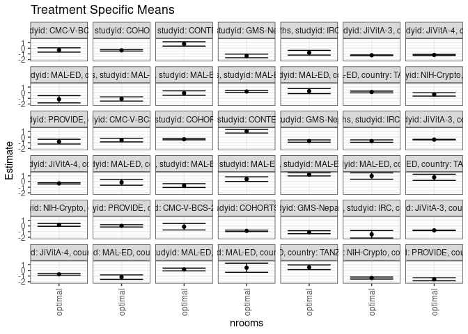

## Results Table

### Parameter: TSM

| agecat | studyid | country | intervention_level | baseline_level | estimate | ci_lower | ci_upper |
| --- | --- | --- | --- | --- | --- | --- | --- |
| Birth | CMC-V-BCS-2002 | INDIA | optimal | observed | -0.1321002 | -0.7092004 | 0.4449999 |
| Birth | COHORTS | INDIA | optimal | observed | -0.8594791 | -0.9875970 | -0.7313612 |
| Birth | GMS-Nepal | NEPAL | optimal | observed | -1.0987723 | -1.3584637 | -0.8390809 |
| Birth | IRC | INDIA | optimal | observed | -1.4735767 | -2.1370974 | -0.8100561 |
| Birth | JiVitA-3 | BANGLADESH | optimal | observed | -0.7779795 | -0.8240007 | -0.7319583 |
| Birth | JiVitA-4 | BANGLADESH | optimal | observed | -0.6891770 | -0.8371239 | -0.5412302 |
| Birth | MAL-ED | BANGLADESH | optimal | observed | -1.1848156 | -1.5819143 | -0.7877169 |
| Birth | MAL-ED | PERU | optimal | observed | 0.1608750 | -0.0831895 | 0.4049395 |
| Birth | MAL-ED | SOUTH AFRICA | optimal | observed | 0.4751621 | -0.3295471 | 1.2798712 |
| Birth | MAL-ED | TANZANIA, UNITED REPUBLIC OF | optimal | observed | 0.5513102 | 0.1346467 | 0.9679737 |
| Birth | NIH-Crypto | BANGLADESH | optimal | observed | -1.3458817 | -1.5238500 | -1.1679134 |
| Birth | PROVIDE | BANGLADESH | optimal | observed | -1.5613819 | -1.8304557 | -1.2923081 |
| 6 months | CMC-V-BCS-2002 | INDIA | optimal | observed | -0.5261304 | -0.8499187 | -0.2023420 |
| 6 months | COHORTS | INDIA | optimal | observed | -0.3793245 | -0.4810024 | -0.2776467 |
| 6 months | CONTENT | PERU | optimal | observed | 1.0400282 | 0.7238978 | 1.3561585 |
| 6 months | GMS-Nepal | NEPAL | optimal | observed | -0.6991681 | -0.9012673 | -0.4970689 |
| 6 months | IRC | INDIA | optimal | observed | -0.7077358 | -0.9208672 | -0.4946045 |
| 6 months | JiVitA-3 | BANGLADESH | optimal | observed | -0.4401071 | -0.4880626 | -0.3921516 |
| 6 months | JiVitA-4 | BANGLADESH | optimal | observed | -0.3300848 | -0.4392104 | -0.2209592 |
| 6 months | MAL-ED | BANGLADESH | optimal | observed | -0.1441509 | -0.6483796 | 0.3600778 |
| 6 months | MAL-ED | INDIA | optimal | observed | -0.7111703 | -1.0465843 | -0.3757562 |
| 6 months | MAL-ED | NEPAL | optimal | observed | 0.4286892 | 0.0197251 | 0.8376532 |
| 6 months | MAL-ED | PERU | optimal | observed | 1.2616067 | 0.9815804 | 1.5416329 |
| 6 months | MAL-ED | SOUTH AFRICA | optimal | observed | 0.9717806 | 0.4084151 | 1.5351461 |
| 6 months | MAL-ED | TANZANIA, UNITED REPUBLIC OF | optimal | observed | 0.7453568 | 0.2025995 | 1.2881141 |
| 6 months | NIH-Crypto | BANGLADESH | optimal | observed | 0.1958624 | -0.0544851 | 0.4462098 |
| 6 months | PROVIDE | BANGLADESH | optimal | observed | 0.0234373 | -0.1805101 | 0.2273848 |
| 24 months | CMC-V-BCS-2002 | INDIA | optimal | observed | -0.3127631 | -0.6923290 | 0.0668028 |
| 24 months | COHORTS | INDIA | optimal | observed | -0.3756408 | -0.5009668 | -0.2503148 |
| 24 months | CONTENT | PERU | optimal | observed | 0.7611060 | 0.3761243 | 1.1460876 |
| 24 months | GMS-Nepal | NEPAL | optimal | observed | -1.3613477 | -1.6809806 | -1.0417147 |
| 24 months | IRC | INDIA | optimal | observed | -0.7944246 | -1.2090201 | -0.3798291 |
| 24 months | JiVitA-3 | BANGLADESH | optimal | observed | -1.2408032 | -1.3023622 | -1.1792442 |
| 24 months | JiVitA-4 | BANGLADESH | optimal | observed | -1.1910304 | -1.2880804 | -1.0939804 |
| 24 months | MAL-ED | BANGLADESH | optimal | observed | -1.1669151 | -1.8049561 | -0.5288741 |
| 24 months | MAL-ED | INDIA | optimal | observed | -1.1108989 | -1.4832037 | -0.7385942 |
| 24 months | MAL-ED | NEPAL | optimal | observed | -0.0743964 | -0.4687877 | 0.3199950 |
| 24 months | MAL-ED | PERU | optimal | observed | 0.2070206 | 0.0355818 | 0.3784593 |
| 24 months | MAL-ED | SOUTH AFRICA | optimal | observed | 0.2784960 | -0.1673742 | 0.7243662 |
| 24 months | MAL-ED | TANZANIA, UNITED REPUBLIC OF | optimal | observed | 0.1190764 | -0.0384908 | 0.2766437 |
| 24 months | NIH-Crypto | BANGLADESH | optimal | observed | -0.3128183 | -0.6046673 | -0.0209694 |
| 24 months | PROVIDE | BANGLADESH | optimal | observed | -0.8021897 | -1.2240872 | -0.3802922 |

### Parameter: E(Y)

| agecat | studyid | country | intervention_level | baseline_level | estimate | ci_lower | ci_upper |
| --- | --- | --- | --- | --- | --- | --- | --- |
| Birth | CMC-V-BCS-2002 | INDIA | observed | observed | -0.4648256 | -0.7643210 | -0.1653302 |
| Birth | COHORTS | INDIA | observed | observed | -0.9778087 | -1.0126530 | -0.9429644 |
| Birth | GMS-Nepal | NEPAL | observed | observed | -1.1164431 | -1.2040134 | -1.0288728 |
| Birth | IRC | INDIA | observed | observed | -1.0053372 | -1.1922119 | -0.8184626 |
| Birth | JiVitA-3 | BANGLADESH | observed | observed | -0.7776536 | -0.7966730 | -0.7586341 |
| Birth | JiVitA-4 | BANGLADESH | observed | observed | -0.6882498 | -0.7406539 | -0.6358456 |
| Birth | MAL-ED | BANGLADESH | observed | observed | -0.9728358 | -1.1217009 | -0.8239707 |
| Birth | MAL-ED | PERU | observed | observed | -0.0468095 | -0.1738806 | 0.0802616 |
| Birth | MAL-ED | SOUTH AFRICA | observed | observed | -0.1729474 | -0.4186222 | 0.0727275 |
| Birth | MAL-ED | TANZANIA, UNITED REPUBLIC OF | observed | observed | 0.7637500 | 0.5676177 | 0.9598823 |
| Birth | NIH-Crypto | BANGLADESH | observed | observed | -1.2441513 | -1.3281130 | -1.1601897 |
| Birth | PROVIDE | BANGLADESH | observed | observed | -1.2984586 | -1.3752758 | -1.2216415 |
| 6 months | CMC-V-BCS-2002 | INDIA | observed | observed | -0.5026766 | -0.6536848 | -0.3516685 |
| 6 months | COHORTS | INDIA | observed | observed | -0.7088012 | -0.7411274 | -0.6764750 |
| 6 months | CONTENT | PERU | observed | observed | 1.0644279 | 0.9468682 | 1.1819876 |
| 6 months | GMS-Nepal | NEPAL | observed | observed | -0.6038416 | -0.6899448 | -0.5177384 |
| 6 months | IRC | INDIA | observed | observed | -0.5900821 | -0.7252457 | -0.4549185 |
| 6 months | JiVitA-3 | BANGLADESH | observed | observed | -0.5930302 | -0.6125738 | -0.5734865 |
| 6 months | JiVitA-4 | BANGLADESH | observed | observed | -0.3901595 | -0.4274150 | -0.3529041 |
| 6 months | MAL-ED | BANGLADESH | observed | observed | -0.1333333 | -0.2623761 | -0.0042906 |
| 6 months | MAL-ED | INDIA | observed | observed | -0.7102872 | -0.8371659 | -0.5834085 |
| 6 months | MAL-ED | NEPAL | observed | observed | 0.1104308 | -0.0208643 | 0.2417259 |
| 6 months | MAL-ED | PERU | observed | observed | 1.0512099 | 0.9285617 | 1.1738581 |
| 6 months | MAL-ED | SOUTH AFRICA | observed | observed | 0.5404351 | 0.3867005 | 0.6941696 |
| 6 months | MAL-ED | TANZANIA, UNITED REPUBLIC OF | observed | observed | 0.5362213 | 0.4049390 | 0.6675036 |
| 6 months | NIH-Crypto | BANGLADESH | observed | observed | 0.0297622 | -0.0491685 | 0.1086930 |
| 6 months | PROVIDE | BANGLADESH | observed | observed | -0.1990907 | -0.2817968 | -0.1163845 |
| 24 months | CMC-V-BCS-2002 | INDIA | observed | observed | -0.5571505 | -0.6585247 | -0.4557763 |
| 24 months | COHORTS | INDIA | observed | observed | -0.6612799 | -0.6944511 | -0.6281088 |
| 24 months | CONTENT | PERU | observed | observed | 0.5902439 | 0.4560143 | 0.7244735 |
| 24 months | GMS-Nepal | NEPAL | observed | observed | -1.1363107 | -1.2252817 | -1.0473398 |
| 24 months | IRC | INDIA | observed | observed | -0.7416790 | -0.8323562 | -0.6510017 |
| 24 months | JiVitA-3 | BANGLADESH | observed | observed | -1.2967966 | -1.3200807 | -1.2735126 |
| 24 months | JiVitA-4 | BANGLADESH | observed | observed | -1.2231776 | -1.2550332 | -1.1913220 |
| 24 months | MAL-ED | BANGLADESH | observed | observed | -0.8192925 | -0.9412667 | -0.6973182 |
| 24 months | MAL-ED | INDIA | observed | observed | -0.9516520 | -1.0670654 | -0.8362385 |
| 24 months | MAL-ED | NEPAL | observed | observed | -0.3749123 | -0.4886073 | -0.2612173 |
| 24 months | MAL-ED | PERU | observed | observed | 0.1111982 | -0.0118399 | 0.2342362 |
| 24 months | MAL-ED | SOUTH AFRICA | observed | observed | 0.4090301 | 0.2879441 | 0.5301161 |
| 24 months | MAL-ED | TANZANIA, UNITED REPUBLIC OF | observed | observed | 0.0547975 | -0.0703378 | 0.1799328 |
| 24 months | NIH-Crypto | BANGLADESH | observed | observed | -0.6103502 | -0.7050157 | -0.5156847 |
| 24 months | PROVIDE | BANGLADESH | observed | observed | -0.8928670 | -0.9755153 | -0.8102187 |

### Parameter: PAR

| agecat | studyid | country | intervention_level | baseline_level | estimate | ci_lower | ci_upper |
| --- | --- | --- | --- | --- | --- | --- | --- |
| Birth | CMC-V-BCS-2002 | INDIA | optimal | observed | -0.3327253 | -0.8671771 | 0.2017264 |
| Birth | COHORTS | INDIA | optimal | observed | -0.1183297 | -0.2467970 | 0.0101377 |
| Birth | GMS-Nepal | NEPAL | optimal | observed | -0.0176708 | -0.2652444 | 0.2299028 |
| Birth | IRC | INDIA | optimal | observed | 0.4682395 | -0.1863374 | 1.1228164 |
| Birth | JiVitA-3 | BANGLADESH | optimal | observed | 0.0003259 | -0.0444636 | 0.0451154 |
| Birth | JiVitA-4 | BANGLADESH | optimal | observed | 0.0009272 | -0.1429139 | 0.1447683 |
| Birth | MAL-ED | BANGLADESH | optimal | observed | 0.2119797 | -0.1830359 | 0.6069954 |
| Birth | MAL-ED | PERU | optimal | observed | -0.2076845 | -0.4495498 | 0.0341808 |
| Birth | MAL-ED | SOUTH AFRICA | optimal | observed | -0.6481094 | -1.4019158 | 0.1056970 |
| Birth | MAL-ED | TANZANIA, UNITED REPUBLIC OF | optimal | observed | 0.2124398 | -0.1952252 | 0.6201048 |
| Birth | NIH-Crypto | BANGLADESH | optimal | observed | 0.1017303 | -0.0567808 | 0.2602414 |
| Birth | PROVIDE | BANGLADESH | optimal | observed | 0.2629233 | -0.0005706 | 0.5264172 |
| 6 months | CMC-V-BCS-2002 | INDIA | optimal | observed | 0.0234537 | -0.2899326 | 0.3368401 |
| 6 months | COHORTS | INDIA | optimal | observed | -0.3294767 | -0.4327377 | -0.2262157 |
| 6 months | CONTENT | PERU | optimal | observed | 0.0243997 | -0.2737787 | 0.3225782 |
| 6 months | GMS-Nepal | NEPAL | optimal | observed | 0.0953265 | -0.0782584 | 0.2689114 |
| 6 months | IRC | INDIA | optimal | observed | 0.1176537 | -0.0390692 | 0.2743767 |
| 6 months | JiVitA-3 | BANGLADESH | optimal | observed | -0.1529231 | -0.2012753 | -0.1045708 |
| 6 months | JiVitA-4 | BANGLADESH | optimal | observed | -0.0600747 | -0.1670148 | 0.0468654 |
| 6 months | MAL-ED | BANGLADESH | optimal | observed | 0.0108176 | -0.4470139 | 0.4686490 |
| 6 months | MAL-ED | INDIA | optimal | observed | 0.0008830 | -0.3071291 | 0.3088952 |
| 6 months | MAL-ED | NEPAL | optimal | observed | -0.3182584 | -0.6954069 | 0.0588902 |
| 6 months | MAL-ED | PERU | optimal | observed | -0.2103968 | -0.4578625 | 0.0370690 |
| 6 months | MAL-ED | SOUTH AFRICA | optimal | observed | -0.4313455 | -0.9689064 | 0.1062154 |
| 6 months | MAL-ED | TANZANIA, UNITED REPUBLIC OF | optimal | observed | -0.2091355 | -0.7191274 | 0.3008564 |
| 6 months | NIH-Crypto | BANGLADESH | optimal | observed | -0.1661001 | -0.4026925 | 0.0704923 |
| 6 months | PROVIDE | BANGLADESH | optimal | observed | -0.2225280 | -0.4119889 | -0.0330670 |
| 24 months | CMC-V-BCS-2002 | INDIA | optimal | observed | -0.2443874 | -0.6113387 | 0.1225639 |
| 24 months | COHORTS | INDIA | optimal | observed | -0.2856391 | -0.4106732 | -0.1606050 |
| 24 months | CONTENT | PERU | optimal | observed | -0.1708621 | -0.5413667 | 0.1996426 |
| 24 months | GMS-Nepal | NEPAL | optimal | observed | 0.2250369 | -0.0763451 | 0.5264189 |
| 24 months | IRC | INDIA | optimal | observed | 0.0527457 | -0.3544360 | 0.4599273 |
| 24 months | JiVitA-3 | BANGLADESH | optimal | observed | -0.0559934 | -0.1168533 | 0.0048665 |
| 24 months | JiVitA-4 | BANGLADESH | optimal | observed | -0.0321472 | -0.1272374 | 0.0629430 |
| 24 months | MAL-ED | BANGLADESH | optimal | observed | 0.3476226 | -0.2772191 | 0.9724644 |
| 24 months | MAL-ED | INDIA | optimal | observed | 0.1592469 | -0.1864517 | 0.5049455 |
| 24 months | MAL-ED | NEPAL | optimal | observed | -0.3005159 | -0.6640961 | 0.0630643 |
| 24 months | MAL-ED | PERU | optimal | observed | -0.0958224 | -0.2073608 | 0.0157160 |
| 24 months | MAL-ED | SOUTH AFRICA | optimal | observed | 0.1305341 | -0.2968920 | 0.5579602 |
| 24 months | MAL-ED | TANZANIA, UNITED REPUBLIC OF | optimal | observed | -0.0642789 | -0.1993937 | 0.0708358 |
| 24 months | NIH-Crypto | BANGLADESH | optimal | observed | -0.2975319 | -0.5677088 | -0.0273549 |
| 24 months | PROVIDE | BANGLADESH | optimal | observed | -0.0906773 | -0.5027630 | 0.3214084 |